# NLP Final Project: Structural Topic Modelling

Ker-Yu Ong

27/06/2018

```r
library(stm)
```

```r
library(igraph)
library(stmCorrViz)
data = read.delim('reviews_clean', sep = '|')
```

# Pre-Processing

`stm`’s `textProcessor` performs stemming and stopword removal.

```r
processed <- textProcessor(data$reviewText, metadata = data)
```

```
## Building corpus...
```

```
## Converting to Lower Case...
## Removing punctuation...
## Removing stopwords...
## Removing numbers...
## Stemming...
## Creating Output...
```

```r
processed
```

```
## A text corpus with 64694 documents, and an 231648 word dictionary.
```

```r
head(processed$documents,1)
```

```
## $`1`
##      [,1] [,2] [,3] [,4] [,5] [,6] [,7] [,8] [,9] [,10] [,11] [,12] [,13]
## [1,] 4656 4730 4883 4954 5587 6219 7612 8752 8847 16638 21393 24140 30655
## [2,]    1    1    1    1    1    1    1    1    1     1     1     1     1
##      [,14] [,15] [,16] [,17] [,18] [,19] [,20] [,21] [,22] [,23] [,24]
## [1,] 44016 46723 47184 48467 49615 52224 54123 59452 60579 61807 66570
## [2,]     1     1     1     1     1     2     1     1     1     3     1
##      [,25] [,26] [,27] [,28] [,29] [,30]  [,31]  [,32]  [,33]  [,34]
## [1,] 69487 81242 84902 87488 91009 91795 107344 110164 111050 113367
## [2,]     1     1     1     1     1     1      1      1      1      1
##       [,35]  [,36]  [,37]  [,38]  [,39]  [,40]  [,41]  [,42]  [,43]  [,44]
## [1,] 117818 117903 119995 120568 127564 128420 130517 137328 141857 145581
## [2,]      1      1      1      1      1      1      2      1      1      1
##       [,45]  [,46]  [,47]  [,48]  [,49]  [,50]  [,51]  [,52]  [,53]  [,54]
## [1,] 148294 163058 168654 169316 169478 172439 174038 174236 185510 187064
## [2,]      1      1      1      1      2      1      1      2      1      1
##       [,55]  [,56]  [,57]  [,58]  [,59]  [,60]  [,61]  [,62]  [,63]  [,64]
## [1,] 187106 187157 189301 190330 191019 191238 193740 205245 206467 207102
## [2,]      1      1      1      1      1      1      1      1      1      1
##       [,65]  [,66]  [,67]  [,68]  [,69]  [,70]  [,71]  [,72]
## [1,] 211197 211736 212073 219870 221818 222821 225964 229347
## [2,]      2      1      1      1      1      1      1      1
```

`prepDocuments` removes low frequency words and documents with a low word count based on a default threshold of 1 (i.e. words that occur only once).

```r
out <- prepDocuments(processed$documents, processed$vocab, processed$meta)
```

```
## Removing 166416 of 231648 terms (166416 of 5163424 tokens) due to frequency
## Removing 2 Documents with No Words
## Your corpus now has 64692 documents, 65232 terms and 4997008 tokens.
```

The object `out` contains `documents`, i.e. the vectorized review:

```r
head(out$documents,1)
```

```
## $`1`
##      [,1] [,2] [,3] [,4] [,5] [,6] [,7] [,8] [,9] [,10] [,11] [,12] [,13]
## [1,] 1281 1345 1363 1545 1729 2446 2466 4461 5729  6490  8344 12005 12765
## [2,]    1    1    1    1    1    1    1    1    1     1     1     1     1
##      [,14] [,15] [,16] [,17] [,18] [,19] [,20] [,21] [,22] [,23] [,24]
## [1,] 12882 13200 13539 14295 14834 16573 16864 18099 18823 22065 23095
## [2,]     1     1     1     2     1     1     3     1     1     1     1
##      [,25] [,26] [,27] [,28] [,29] [,30] [,31] [,32] [,33] [,34] [,35]
## [1,] 23779 24771 24971 29258 30000 30218 30840 32070 32813 34768 35008
## [2,]     1     1     1     1     1     1     1     1     1     1     1
##      [,36] [,37] [,38] [,39] [,40] [,41] [,42] [,43] [,44] [,45] [,46]
## [1,] 35598 37478 38729 39791 46131 47674 47882 49158 49206 52444 52870
## [2,]     2     1     1     1     1     1     2     1     2     1     1
##      [,47] [,48] [,49] [,50] [,51] [,52] [,53] [,54] [,55] [,56] [,57]
## [1,] 52887 53452 54014 54705 58195 58399 59479 59632 59740 62000 62563
## [2,]     1     1     1     1     1     1     2     1     1     1     1
##      [,58] [,59] [,60]
## [1,] 62817 63694 64585
## [2,]     1     1     1
```

`vocab`, i.e. the review tokens:

```r
head(out$vocab, 10)
```

```
##  [1] "---"         "---box"      "---floor"    "---great"    "---luck"
##  [6] "---map"      "---ordinari" "---place"    "---world"    "--ahalf"
```

```r
tail(out$vocab, 10)
```

```
##  [1] "zuehl"  "zug"    "zulu"   "zumba"  "zune"   "zuton"  "zwan"
##  [8] "zydeco" "zygot"  "zztop"
```

as well as `meta`, the review metadata or covariate information:

```r
head(out$meta,1)
```

```
##   X
## 1 0
##                                                                                                                                                                                                                                                                                                          …
## 1 It's hard to believe "Memory of Trees" came out 11 years ago;it has held up well over the passage of time.It's Enya's last great album before the New Age/pop of "Amarantine" and "Day without rain." Back in 1995,Enya still had her creative spark,her own voice.I agree with the reviewer who said t…
##   sent_sign helpful_prop overall reviewYear
## 1         1            1       5       2006
```

Let’s save these out to variables:

```r
docs <- out$documents
vocab <- out$vocab
meta <- out$meta
```

# Model Fitting

Let’s now fit various STM models and see how topics vary with different covariates. We use `init.type = "Spectral"` to specify spectral initialization via spectral decomposition (non-negative matrix factorization) of the word co-occurrence matrix. The developers of STM generally recommend using the spectral initialization as they’ve found it to produce the best results consistently (Roberts et al. 2016a).

## Model 1: Sentiment as Covariate

First, using `sent_sign`, i.e. review sentiment, as our covariate:

```r
fit1 <- stm(out$documents, out$vocab, K=5, prevalence=~sent_sign, max.em.its=100, data=out$meta, init.type="Spectral", seed=42)
```

[output not shown]

[output cut: 448 more lines]

```
## Completed E-Step (12 seconds).
## Completed M-Step.
## Completing Iteration 97 (approx. per word bound = -7.635, relative change = 1.780e-05)
## ....................................................................................................
## Completed E-Step (12 seconds).
## Completed M-Step.
## Completing Iteration 98 (approx. per word bound = -7.635, relative change = 1.724e-05)
## ....................................................................................................
## Completed E-Step (13 seconds).
## Completed M-Step.
## Completing Iteration 99 (approx. per word bound = -7.635, relative change = 1.681e-05)
## ....................................................................................................
## Completed E-Step (12 seconds).
## Completed M-Step.
## Model Terminated Before Convergence Reached
```

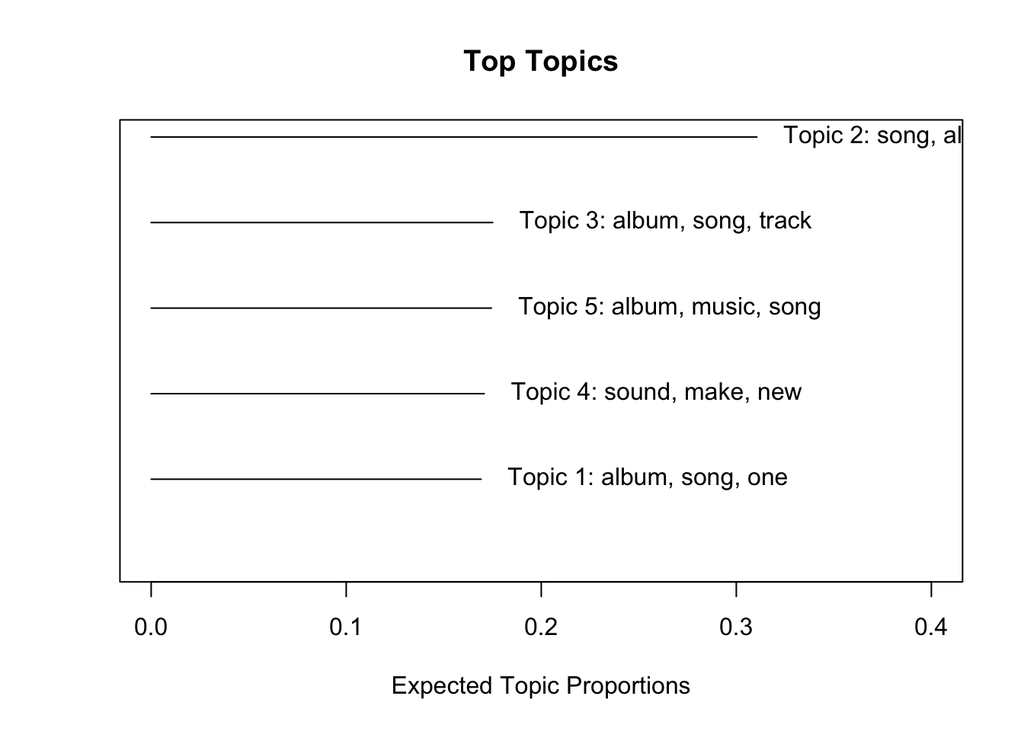

```r
plot(fit1, type="summary", xlim=c(0,.4))
```

We see that topic 2 has the highest expected proportion whereas topic 1 has the lowest. At first glance, these topics seem rather generic and non-distinguishable, but we can also look at their constituent words using other metrics.

First, let’s look at the constituent words ranked by probability:

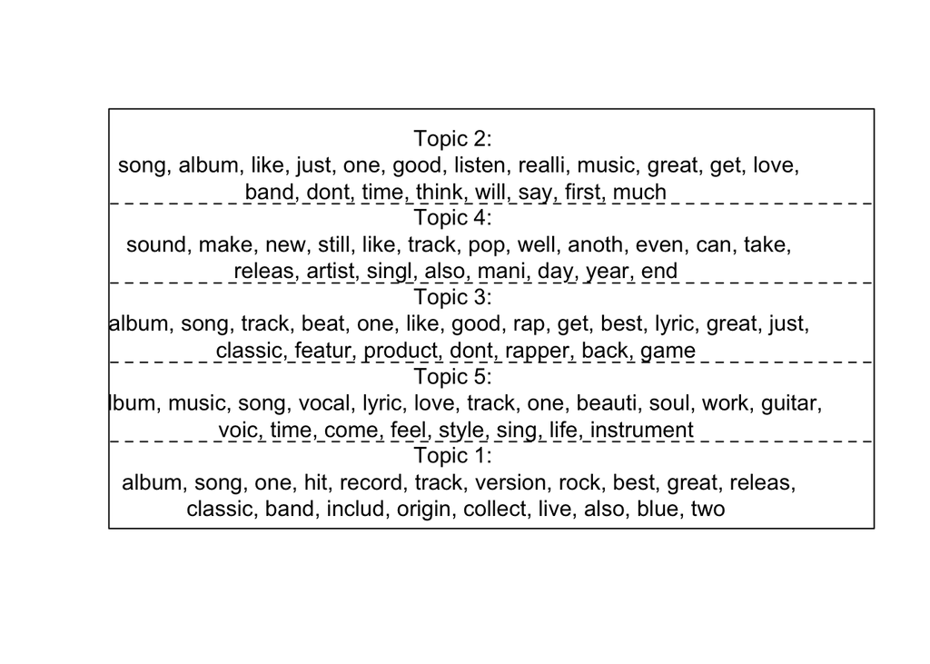

```r
plot(fit1, type="labels", topics=c(2,4,3,5,1))
```

We can compare the highest and lowest proportion topics as follows:

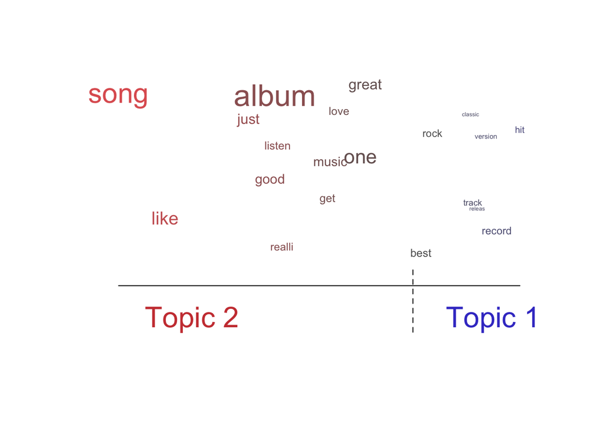

```r
plot(fit1, type="perspectives", topics=c(2,1))
```

We can also look consitutent words using other metrics:

```r
labelTopics(fit1, c(2,4,3,5,1))
```

```
## Topic 2 Top Words:
##       Highest Prob: song, album, like, just, one, good, listen
##       FREX: tori, linkin, weezer, incubus, emo, opeth, daft
##       Lift: -girlfriend, -no, -rollin, -ton, acornsquot, acoustic-ish, acsh
##       Score: band, tori, realli, song, like, metal, good
## Topic 4 Top Words:
##       Highest Prob: sound, make, new, still, like, track, pop
##       FREX: cyndi, furtado, idol, shakira, princ, corgan, oral
##       Lift: ahora, aunqu, bastant, cada, calidad, cerati, cierto
##       Score: pop, sound, new, anoth, wave, talent, artist
## Topic 3 Top Words:
##       Highest Prob: album, song, track, beat, one, like, good
##       FREX: rap, rapper, eminem, hop, pac, dre, lil
##       Lift: --hustler, -guest, aight, akon, amerikka, atquot, begotten
##       Score: rapper, pac, rap, eminem, dre, nas, jay-z
## Topic 5 Top Words:
##       Highest Prob: album, music, song, vocal, lyric, love, track
##       FREX: madonna, joss, winehous, mclachlan, sarah, fumbl, ecstasi
##       Lift: --fact, --worthi, -not, -polit, -tro, -wrought, acost
##       Score: vocal, guitar, beauti, melodi, madonna, arrang, ballad
## Topic 1 Top Words:
##       Highest Prob: album, song, one, hit, record, track, version
##       FREX: elton, remast, phil, hendrix, eagl, halen, reissu
##       Lift: denver, gilmour, hatter, loggin, madison, mca, mingus
##       Score: elton, band, remast, halen, hendrix, mccartney, guitar
```

The FREX metric, which weights words by their overall frequency and how exclusive they are to the topic, seems most informative. We can start to distinguish topics by genre.

## Model 2: Product Rating as Covariate

Let’s create another model using `overall` (product rating) as the covariates:

```r
# using 20 iterations for knitting sake; ideally, you'd want 75-100 iterations
fit2 <- stm(out$documents, out$vocab, K=5, prevalence=~overall, max.em.its=20, data=out$meta, init.type="Spectral", seed=42)
```

[output not shown]

[output cut: 48 more lines]

```
## Completed E-Step (14 seconds).
## Completed M-Step.
## Completing Iteration 17 (approx. per word bound = -7.668, relative change = 2.297e-04)
## ....................................................................................................
## Completed E-Step (14 seconds).
## Completed M-Step.
## Completing Iteration 18 (approx. per word bound = -7.666, relative change = 2.147e-04)
## ....................................................................................................
## Completed E-Step (14 seconds).
## Completed M-Step.
## Completing Iteration 19 (approx. per word bound = -7.665, relative change = 2.033e-04)
## ....................................................................................................
## Completed E-Step (14 seconds).
## Completed M-Step.
## Model Terminated Before Convergence Reached
```

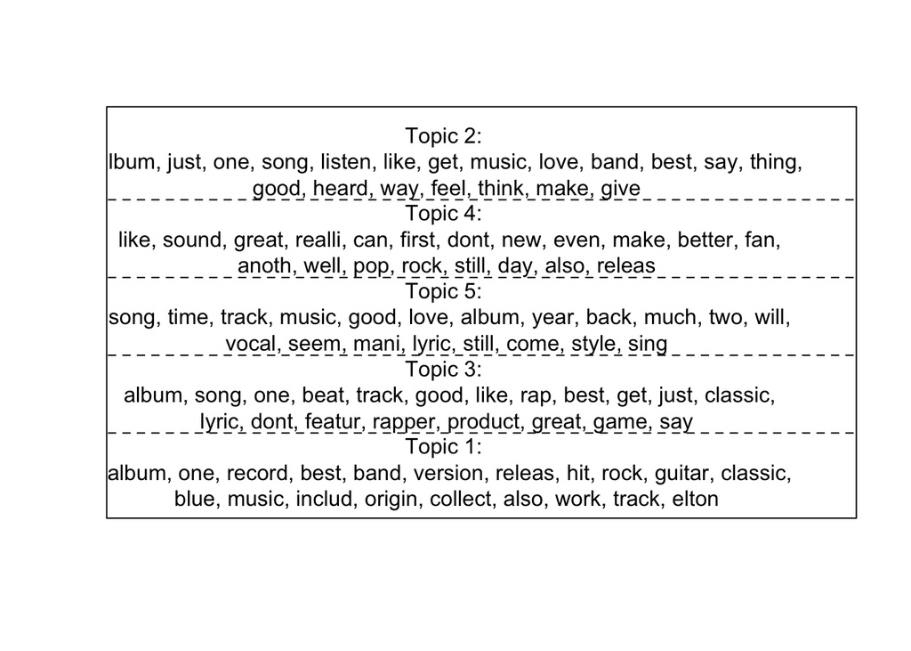

```r
plot(fit2, type="labels", topics=c(2,4,5,3,1))
```

Let’s explore the highest and lowest proportional topics

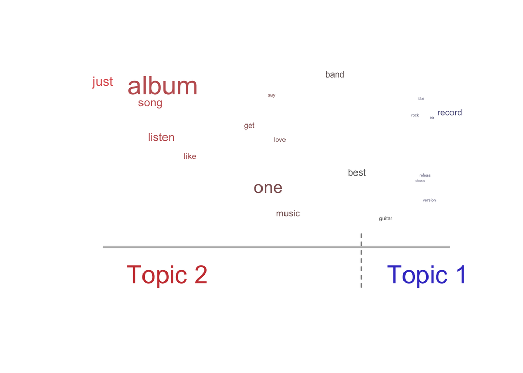

```r
plot(fit2, type="perspectives", topics=c(2,1))
```

Other word metrics:

```r
labelTopics(fit2, c(2,4,5,2,1))
```

```
## Topic 2 Top Words:
##       Highest Prob: album, just, one, song, listen, like, get
##       FREX: incubus, serj, b-s, cedric, suey, primus, nu-met
##       Lift: aerodynamik, dancingi, poemi, vehiclequot, clintonampcrew, suckdont, quotiowaquot
##       Score: album, just, band, listen, one, tori, song
## Topic 4 Top Words:
##       Highest Prob: like, sound, great, realli, can, first, dont
##       FREX: funk, today, youll, somewhat, moment, simpli, day
##       Lift: meno, destacado, tampoco, eacutepoca, claro, absoluto, alta
##       Score: sound, better, anoth, realli, like, great, dont
## Topic 5 Top Words:
##       Highest Prob: song, time, track, music, good, love, album
##       FREX: year, howev, scene, drive, result, jewel, longer
##       Lift: hembi, falsetto-sung, duval, lavern, beneacutet, argentinael, hernan
##       Score: song, year, time, vocal, back, ballad, style
## Topic 2 Top Words:
##       Highest Prob: album, just, one, song, listen, like, get
##       FREX: incubus, serj, b-s, cedric, suey, primus, nu-met
##       Lift: aerodynamik, dancingi, poemi, vehiclequot, clintonampcrew, suckdont, quotiowaquot
##       Score: album, just, band, listen, one, tori, song
## Topic 1 Top Words:
##       Highest Prob: album, one, record, best, band, version, releas
##       FREX: blackmor, jobim, becker, gilberto, paic, donovan, fagen
##       Lift: bassian, bassmax, bonfa, catalogueso, catchypop-rock, charlemagnequot, collosus
##       Score: elton, band, album, guitar, remast, blue, rock
```

## Model 3: Review Year as Covariate

```r
# using 20 iterations for knitting sake; ideally, you'd want 75-100 iterations
fit3 <- stm(out$documents, out$vocab, K=5, prevalence=~reviewYear, max.em.its=20, data=out$meta, init.type="Spectral", seed=42)
```

[output not shown]

[output cut: 48 more lines]

```
## Completed E-Step (14 seconds).
## Completed M-Step.
## Completing Iteration 17 (approx. per word bound = -7.668, relative change = 2.277e-04)
## ....................................................................................................
## Completed E-Step (14 seconds).
## Completed M-Step.
## Completing Iteration 18 (approx. per word bound = -7.666, relative change = 2.131e-04)
## ....................................................................................................
## Completed E-Step (14 seconds).
## Completed M-Step.
## Completing Iteration 19 (approx. per word bound = -7.665, relative change = 2.020e-04)
## ....................................................................................................
## Completed E-Step (14 seconds).
## Completed M-Step.
## Model Terminated Before Convergence Reached
```

Visualize constituent words:

```r
labelTopics(fit3, c(2,4,5,2,1))
```

```
## Topic 2 Top Words:
##       Highest Prob: album, one, just, song, listen, like, music
##       FREX: incubus, serj, b-s, cedric, suey, primus, chevell
##       Lift: aerodynamik, dancingi, poemi, clintonampcrew, herget, aoti, suckdont
##       Score: album, just, band, listen, one, tori, song
## Topic 4 Top Words:
##       Highest Prob: like, sound, great, realli, can, first, dont
##       FREX: funk, today, youll, moment, somewhat, simpli, day
##       Lift: meno, destacado, tampoco, claro, eacutepoca, absoluto, alta
##       Score: sound, better, anoth, realli, great, like, dont
## Topic 5 Top Words:
##       Highest Prob: song, time, track, music, good, album, year
##       FREX: year, howev, scene, drive, result, jewel, longer
##       Lift: hembi, falsetto-sung, duval, beneacutet, vendedor, argentinael, hernan
##       Score: song, year, time, vocal, back, ballad, style
## Topic 2 Top Words:
##       Highest Prob: album, one, just, song, listen, like, music
##       FREX: incubus, serj, b-s, cedric, suey, primus, chevell
##       Lift: aerodynamik, dancingi, poemi, clintonampcrew, herget, aoti, suckdont
##       Score: album, just, band, listen, one, tori, song
## Topic 1 Top Words:
##       Highest Prob: album, one, record, best, band, version, releas
##       FREX: blackmor, jobim, becker, gilberto, paic, donovan, fagen
##       Lift: bassian, bassmax, bonfa, catchypop-rock, collosus, contributionswarm, cornerfleetwood
##       Score: elton, band, album, guitar, blue, remast, rock
```

# Estimating Covariate Effect

We can estimate the effect of covariate on topic emergence using `estimateEffect` and visualize it as follows:

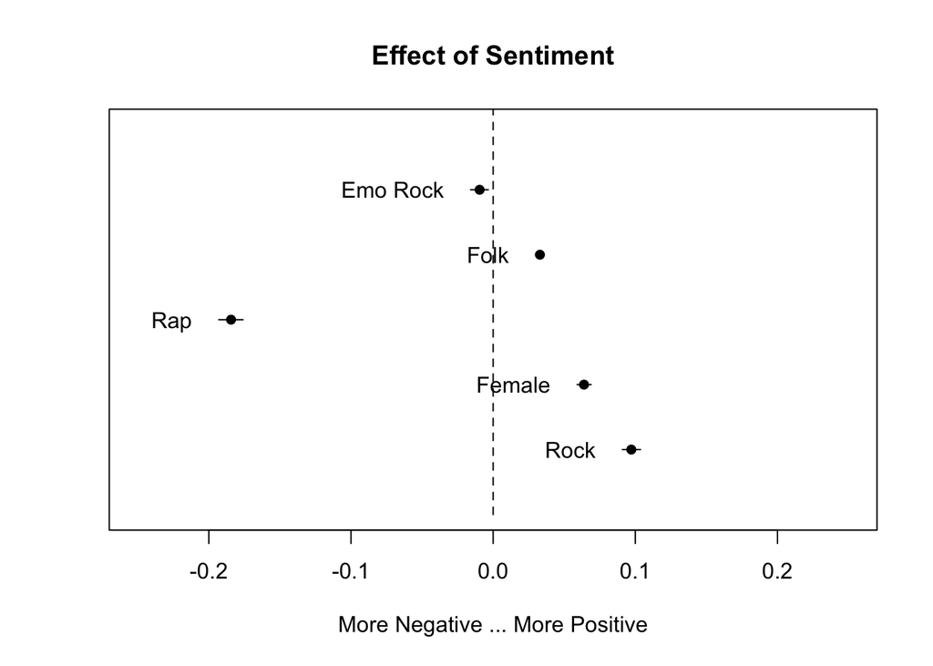

```r
out$meta$sent_sign <- as.factor(out$meta$sent_sign)
prep <- estimateEffect(1:5 ~ sent_sign, fit1, meta=out$meta,  uncertainty="Global")
plot(prep, covariate="sent_sign", topics=c(2, 4, 3, 5, 1), model=fit1, method="difference", cov.value1="1", cov.value2="0", xlab="More Negative ... More Positive", main="Effect of Sentiment", xlim=c(-.25,.25), labeltype ="custom", custom.labels=c('Emo Rock', 'Folk', 'Rap', 'Female', 'Rock'))
```

# Finding Optimal Number of Topics with `searchK()`

```r
# This takes ages to run so do not evaluate. See slide on searchK in presentation deck.
kResult <- searchK(out$documents, out$vocab, K=c(5,20), prevalence=~overall+reviewYear,data=meta)
```

```r
kResult
```

[output not shown]

```r
plot(kResult)
```

[output not shown]